# Social Network Analysis untuk ‘Quweenjojo’: karena delusi setitik, tidak ada yang salah?

Samuel Gema

10/03/2022

# About

Artikel ini merupakan bagian dari *Exploratory Data Analysis* untuk pengembangan dashboard [`AKSATA`](https://samuelgema.shinyapps.io/aksata_check). Query twitter search “Quweenjojo” menarik untuk dibahas karena pemilik akun twitter “Quweenjojo” sempat menjadi pusat perhatian warganet pada pertengahan 2021 dan Awal Februari 2022 yang lalu.

## Quweenjojo dan klaim kekerasan seksual

[figure not shown]

```r
knitr::include_graphics("input/jojoquween.png")
```

Tweet permintaan maaf yang viral pada awal Februari 2022 membawa warganet teringat dengan pernyataan Quweenjojo pada pertengahan tahun 2021 lalu. Saat itu ia mengklaim bahwa telah mendapat perlakuan kurang pantas (pelecehan seksual) dari seorang penyiar radio bernama Gofar Hilman, pada tahun 2018.

Reaksi warganet menanggapi viralnya kembali Quweenjojo cukup beragam. Pada umumnya mereka bingung untuk menentukan standing positionnya terhadap kasus ini–antara merasa bingung atas sikap Quweenjojo; ada yang mencurigai Gofar Hilman memaksa Quweenjojo memberikan pernyataan palsu; ada pula yang prihatin dan memberi semangat terhadap kondisi kesehatan mental Quweenjojo.  
Memang sempat diakui kalau Quweenjojo menderita skizofrenia, dan sering mengalami hal-hal delusional.

Terlepas dari sentimen warganet, Analisis SNA ini dibuat untuk memahami pola pembicaraan yang terbentuk berdasarkan aktivitas mention/replies maupun quote tweet.

Data diambil menggunakan bahasa pemrograman R dan package `Rtweet`. Anda dapat melihat dokumentasi https://github.com/ropensci/rtweet untuk mengambil data melalui [API twitter](http://developer.twitter.com) (open in new tab).

Dataset diambil beberapa hari pasca viralnya tweet, dengan jumlah observasi yang didapatkan sebanyak 10294 tweets.

# SNA Workflow

## Memuat Library

```r
library(tidyverse)
library(igraph)
library(sigmajs)
library(graphTweets)
```

## Memuat dan melihat struktur data

```r
raw_data <- readRDS("quweenjojo.rds")
glimpse(raw_data)
```

```
#> Rows: 10,294
#> Columns: 35
#> $ created_at                    <chr> "Sat Feb 12 05:37:48 +0000 2022", "Fri F~
#> $ id                            <dbl> 1492372346107473920, 1492171619892338688~
#> $ id_str                        <chr> "1492372346107473921", "1492171619892338~
#> $ full_text                     <chr> "Selain kamera yang dipasang si Mbak seb~
#> $ truncated                     <lgl> FALSE, FALSE, FALSE, FALSE, FALSE, FALSE~
#> $ display_text_range            <dbl> 181, 61, 66, 51, 63, 140, 23, 77, 140, 5~
#> $ entities                      <list> [[<data.frame[1 x 2]>], [<data.frame[1 ~
#> $ metadata                      <list> [<data.frame[1 x 2]>], [<data.frame[1 x~
#> $ source                        <chr> "<a href=\"https://mobile.twitter.com\" ~
#> $ in_reply_to_status_id         <dbl> NA, NA, NA, 1492175242235871232, 1493196~
#> $ in_reply_to_status_id_str     <chr> NA, NA, NA, "1492175242235871233", "1493~
#> $ in_reply_to_user_id           <dbl> NA, NA, NA, 719755682908491776, 11192604~
#> $ in_reply_to_user_id_str       <chr> NA, NA, NA, "719755682908491781", "11192~
```

[output cut: 22 more lines]

Package `rtweet` versi 0.7.900 menghasilkan metadata yang berbeda dengan versi sebelumnya. Metadata Rtweet versi terbaru berbentuk nested dataframe. Maka dari itu, saya harus menormalisasi data ke bentuk yang lebih sederhana dan mudah digunakan untuk clustering.

# Data Preprocessing

## Subset dan normalisasi variabel “retweeted status”

```r
# Subset dan normalisasi variabel "retweeted status"

ret_status_user <- raw_data %>%
  select(retweeted_status) %>%
  unnest_wider(retweeted_status) %>%
  rename(created_at_retweet = created_at) %>%
  rename(id_ret = id) %>%
  rename(id_str_ret = id_str) %>%
  select(
    -entities,
    -lang,
    -metadata,
    -source,
    -truncated,
    -in_reply_to_status_id,
    -in_reply_to_status_id_str,
    -in_reply_to_user_id
  ) %>%
  rename(text_ret = full_text) %>%
  unnest_wider(user) %>%
  rename(description_user = description) %>%
  rename(attached_url = url) %>%
  # select(-...1) %>%
  unnest_wider(entities) %>%
  select(
    -display_text_range,
    -description,
    -quoted_status,
    -extended_entities,
    -place,
    -withheld_in_countries
  )
```

## Mengambil hanya list “entities”

```r
# List "user_mentions" terdapat pada variabel entities, saya harus mengubahnya menjadi list

to_mentions <- raw_data %>%
  select(entities) %>%
  mutate(entities = as.list(entities))

head(to_mentions)
```

|  | entities |
| --- | --- |
| 1 |  |
| 2 |  |
| 3 |  |
| 4 |  |
| 5 |  |
| 6 |  |

## Subset list `screen_name` di dalam list `entities` dan `user_mentions`

```r
list_mention <- lapply(to_mentions$entities, function(x) {x[["user_mentions"]]$screen_name})

# Mengubah hasil subset menjadi character list c("","")

mentions_chr <- unlist(unlist(as.character(list_mention)))
```

## Finalisasi struktur data

```r
# Settling object ret_status_user dengan menambahkan character list,
# menghilangkan tweet tanpa interaksi mention/reply

object_fix <- ret_status_user %>%
  mutate(mentions_screen_name = mentions_chr)%>%
  mutate(mentions_screen_name = ifelse(
    mentions_screen_name == "NA",
    NA,
    as.character(mentions_screen_name))) %>%
  drop_na(text_ret) %>%
  mutate(mentions_screen_name = ifelse(mentions_screen_name == screen_name, NA, as.character(mentions_screen_name))) %>%
  select(-url)

# Subset hanya variabel yang dibutuhkan

cleansing <- object_fix %>%
  select(screen_name, mentions_screen_name, name)
```

```r
# Mengkonversi character list c("","") menggunakan notasi regular expression

tweets <-
  cleansing %>%
  mutate(
    mentions_screen_name = str_replace_all(
      string = mentions_screen_name,
      pattern = "^c\\(|\\)$",
      replacement = ""
    )
  ) %>%
  separate_rows(mentions_screen_name, sep = ",") %>%
  na.omit() %>%
  mutate(
    mentions_screen_name = str_replace_all(
      string = mentions_screen_name,
      pattern = "[[:]]+",
      replacement = ""
    )
  ) %>%
  rename(from = screen_name,
         to = mentions_screen_name) %>%

  mutate(to = str_replace_all(
    string = to,
    #to,
    pattern = "\"",
    replacement = ""
  ))

tweets
```

| from | to | name |
| --- | --- | --- |
| bahanaFC | bahanaFC | Penyalin Catatan Teman |
| bahanaFC | anjirkurinjir | Penyalin Catatan Teman |
| bahanaFC | feykenschupid | Penyalin Catatan Teman |
| bahanaFC | quweenjojo | Penyalin Catatan Teman |
| _ariskaf | _ariskaf | Ariska |
| _ariskaf | quweenjojo | Ariska |
| dimasssagungp | dimasssagungp | Dimas |
| dimasssagungp | Finasepti_ | Dimas |
| dimasssagungp | quweenjojo | Dimas |
| feykenschupid | feykenschupid |  |

[output cut: 2662 more lines]

## Visualisasi menggunakan `graphTweets` dan `SigmaJs`

```r
gt <- tweets %>%
  gt_edges(from, to) %>%
  gt_nodes() %>%
  gt_collect()

# transform ke dataframe nodes dan edges (agar nantinya mudah dibaca oleh shiny)

tmp_nodes <- gt$nodes %>% as.data.frame()

tmp_edges <- gt$edges %>% as.data.frame()

nodes <- tmp_nodes %>%
  mutate(
    id = nodes,
    label = nodes,
    size = n,
    color = "#337def"
  )

edges <- tmp_edges %>%
  mutate(id = 1:n())

sigmajs() %>%
  sg_force_start() %>%
  sg_nodes(nodes, id, label, size, color) %>%
  sg_edges(edges, id, source, target) %>%
  sg_force_stop(15000)
```

[interactive chart not shown]

Nodes dari visualisasi ini hoverable (untuk melihat username pada klaster). Visualisasi juga dapat di zoom sesuai keinginan.

Dapat kita lihat bahwa interaksi warganet pada topik “Quweenjojo” membentuk satu klaster utama dan beberapa klaster *clique*/*ngerumpi*. Klaster utama berisikan orang-orang yang secara jelas menyebut nama akun “@quweenjojo” di dalam tweetnya. Dalam kata lain, dapat kita simpulkan bahwa lebih banyak reaksi warganet yang langsung membalas tweet klarifikasi dari quweenjojo; daripada mereka yang melakukan “quote tweet” secara tidak langsung.

Berdasarkan visualisasi di atas, terdapat beberapa klaster “clique” yang berbentuk nodes-nodes kecil di sekeliling klaster besar. Pada topik ini, clique terbentuk dari interaksi tidak langsung atau “quote tweet”.

# Inspect

## (Sebagian) Interaksi username yang terhubung dengan username “Quweenjojo”

```r
target <-
  c(
    "HanienNia",
    "Aermani_",
    "AdalardBanim",
    "agusatriawibawa",
    "LaxusRalenion",
    "chumaidijusuf",
    "fairyfoxlady",
    "_bernacleboy",
    "cyborgrunge",
    "riodwinurhafizh"
  )

object_fix %>%
  distinct() %>%
  select(text_ret, screen_name, mentions_screen_name, id_str_ret) %>%
  filter(screen_name %in% target)
```

| text_ret | screen_name | mentions_screen_name | id_str_ret |
| --- | --- | --- | --- |
| @quweenjojo @efenerr Kayak film Penyalin Cahaya ga sih, menguras menutup mengubur, menguras menutup mengubur. Pada akhirnya korban pelecehan seksual dipaksa diam dan mengubur ceritanya. | HanienNia | c("HanienNia", "quweenjojo", "efenerr") | 1492141382106255363 |
| @quweenjojo Ok now im real worried, i hope you’re okay and not under any pressure uploading this. | fairyfoxlady | c("fairyfoxlady", "quweenjojo") | 1492144037272248322 |
| @quweenjojo wadoohhh...klo ending nya begini nanti korban yg benran korban pelecehan pas speak up bakal di sepelein sih -____- | LaxusRalenion | c("LaxusRalenion", "quweenjojo") | 1492142158844813320 |
| @quweenjojo I don't get it, bukannya korban KSnya ada beberapa dan udah dikumpulin buktinya dari masing2? | Aermani_ | c("Aermani_", "quweenjojo") | 1492143565367316480 |
| @quweenjojo damn penyalin cahaya scene seems so real | cyborgrunge | c("cyborgrunge", "quweenjojo") | 1492142974309842945 |
| @lowpolymale1 @MissingHeavens @quweenjojo Bisa banget ini betina diaduin balik pencemaran nama baik pakai UU ITE biar membusuk di penjara. Mantap bener bikin karir dan hidup orang rusak krn halusinasi… | chumaidijusuf | c("chumaidijusuf", "lowpolymale1", "MissingHeavens", "quweenjojo") | 1492155737120079872 |
| @urfavnightmare_ @yummyxcream @quweenjojo Posko SJW reaktif taikuda | chumaidijusuf | c("chumaidijusuf", "urfavnightmare_", "yummyxcream", "quweenjojo") | 1492155276879101958 |
| @suneshiine @beruangmiskinn @Aermani_ @quweenjojo thread kumpulan korban KSnya juga udah dihapus sama mbanya, dan kalo emang itu gegara mbanya berimajinasi kenapa ada korban lain yang speak up?? ditam… | _bernacleboy | c("_bernacleboy", "suneshiine", "beruangmiskinn", "Aermani_", "quweenjojo") | 1492150016961822726 |
| @shidhev98 @HanienNia @quweenjojo @efenerr Tapi faktanya mmg tdk ada bukti kongkrit kalo si gofar melecehkan si terduga korban, dari awal sih saya merujuk ke situ ya. tambah si korban skrng ngaku kalo… | agusatriawibawa | c("agusatriawibawa", "shidhev98", "HanienNia", "quweenjojo", "efenerr") | 1492145595775000583 |
| @rentheaperra @quweenjojo di ceritany tokoh utama cweknya yang kena ks terpaksa "mengubur" sendiri kasusny soalnya blio powerless (maaf kalo spoiler) | cyborgrunge | c("cyborgrunge", "rentheaperra", "quweenjojo") | 1492148989810016259 |

[output cut: 5 more lines]

## Beberapa nodes klaster “Clique”/ *ngerumpi*

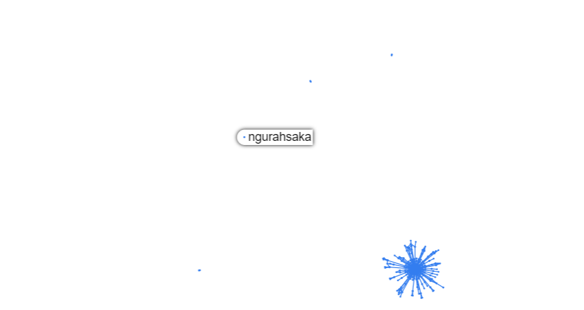

```r
knitr::include_graphics("input/ngurahsaka.png")
```

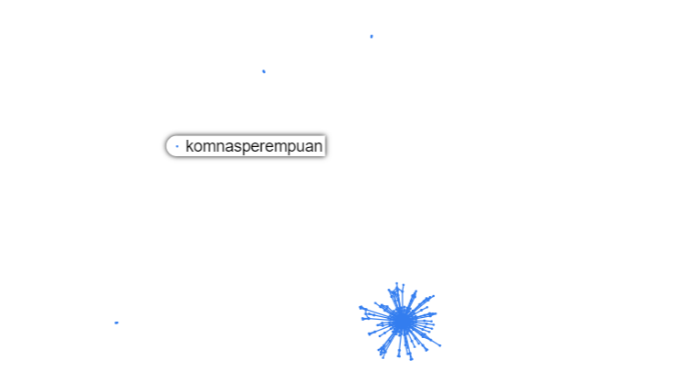

```r
knitr::include_graphics("input/komnasperempuan.png")
```

## Inspect: interaksi klaster “cliques”

```r
library(dplyr)
target2 <-
  c(
    "ngurahsaka",
    "komnasperempuan",
    "sentrisman",
    "f_andhikaa",
    "ence_dwi",
    "araghutama",
    "adefs97",
    "backfirecricket"
  )

object_fix %>%
  distinct() %>%
  select(text_ret, screen_name, mentions_screen_name, id_str_ret) %>%
  filter(screen_name %in% target2)
```

| text_ret | screen_name | mentions_screen_name | id_str_ret |
| --- | --- | --- | --- |
| @adefs97 Ini buya https://t.co/XocnrrVB9a | f_andhikaa | c("f_andhikaa", "adefs97") | 1492168980404260864 |
| wkwkwk ngakak jadinya. dah dibilangin kasus bgini mah tricky. ga ada bukti bisa jd fitnah. so, liat chase begini mestinye cover both side dan terapin asas praduga tak bersalah. asal nuduh bahaya soaln… | sentrisman | NA | 1492145738347728898 |
| Gue ramal ya @sentrisman pasti bakal ada sjw yang bilang kalo gofar itu punya kuasa(power)yang lebih besar dan mbanya ini disudutin sama pihak gofar. Mereka-mereka ini masih percaya kalo gofar adalah … | backfirecricket | c("backfirecricket", "sentrisman") | 1492142149793906688 |
| Menunggu suara @KomnasPerempuan terkait hal ini, biar clear. https://t.co/yxIEfbS9kk | ngurahsaka | c("ngurahsaka", "KomnasPerempuan") | 1492140467030720512 |
| Ini yg dikhawatirkan mas @Araghutama dulu. Tuduhan belum jelas tapi image org udh hancur. https://t.co/uaBm9y8I37 | ence_dwi | c("ence_dwi", "Araghutama") | 1492141451081576450 |

# Final Analysis

Berdasarkan hasil visualisasi SNA dan inspect tweets, ternyata narasi yang dikemukakan antara klaster clique dengan klaster utama sedikit berbeda. Klaster clique lebih didominasi mereka yang sudah memiliki standing position terhadap topik: antara mengambil sikap netral, negatif, atau justru ingin memperluas diskursus (secara terpisah) dengan *circle* mereka sendiri.

Besar dan terpusatnya visualisasi klaster utama pada satu username (yakni Quweenjojo), melambangkan banyaknya orang yang merespon tweet Quweenjojo secara langsung; juga dengan narasi yang sifatnya langsung pula (seperti: *“I don’t get it…”*; *“Ok now im real worried, i hope you’re okay and not under any pressure…”*)

Berfokus pada pemilik akun Quweenjojo, sudah tentu apa yang ia lakukan membuat kegaduhan di media sosial dan kehidupan orang yang tertuduh. Namun, kira-kira sekitar satu minggu setelah viralnya tweet permintaan maaf, Gofar Hilman menceritakan kondisi Quweenjojo yang sesungguhnya, di dalam sebuah podcast.

Bagi penderita gangguan mental, mengakui kesalahan merupakan tindakan yang sulit dan patut kita apresiasi.

Hanya mereka yang bertanggung jawab menangani kesehatan mental Quweenjojo yang mampu memberi keterangan dengan lebih jelas. Namun pasti, sifat dari informasi tersebut sangatlah personal.